# CSCI E-63C: Week 6 Problem Set

Erik Lee

# Preface

In this problem set we will exercise some of the unsupervised learning approaches on [2016 Global Health Observatory data](http://www.who.int/gho/publications/world_health_statistics/2016/en/). It is available at that website in the form of [Excel file](http://www.who.int/entity/gho/publications/world_health_statistics/2016/whs2016_AnnexB.xls?ua=1), but its cleaned up version ready for import into R for further analyses is available at CSCI E-63C canvas course web site [whs2016_AnnexB-data-wo-NAs.txt](https://canvas.harvard.edu/files/6123649/download?download_frd=1). The cleaning and reformatting included: merging data from the two parts of Annex B, reducing column headers to one line with short tags, removal of “>”, “<” and whitespaces, conversion to numeric format and replacement of undefined values (as indicated by en-dash’es in the Excel) with corresponding averages of those attributes. The code that was used to format merged data is shown at the end of this document for your reference only. You are advised to save yourself that trouble and start from preformatted text file available at the course website as shown above. The explicit mapping of short variable names to their full description as provided in the original file is available in Excel file [whs2016_AnnexB-reformatted.xls](https://canvas.harvard.edu/files/6123599/download?download_frd=1) also available on the course canvas page. Lastly, you are advised to download a local copy of this text file to your computer and access it there (as opposed to relying on R ability to establish URL connection to canvas that potentially requires login etc.)

Short example of code shown below illustrates reading this data from a local copy on your computer (assuming it has been copied into current working directory of your R session – `getwd()` and `setwd()` commands are helpful to find out what is it currently and change it to desired location) and displaying summaries and pairs plot of five (out of almost 40) arbitrary chosen variables. This is done for illustration purposes only – the problems in this set expect use of all variables in this dataset.

```r
whsAnnBdatNum <- read.table("whs2016_AnnexB-data-wo-NAs.txt",sep="\t",header=TRUE,quote="")
summary(whsAnnBdatNum[,c(1,4,7,10,17)])
```

```
##      TOTPOP          LIFEXPB.B       MEDBIRTHS          NEWHIV
##  Min.   :      2   Min.   :50.10   Min.   :  9.00   Min.   : 0.100
##  1st Qu.:   1876   1st Qu.:66.03   1st Qu.: 78.50   1st Qu.: 0.300
##  Median :   8070   Median :72.50   Median : 96.00   Median : 1.563
##  Mean   :  37696   Mean   :71.29   Mean   : 84.28   Mean   : 1.563
##  3rd Qu.:  26413   3rd Qu.:76.38   3rd Qu.: 99.00   3rd Qu.: 1.563
##  Max.   :1383925   Max.   :83.70   Max.   :100.00   Max.   :20.100
##      ALCONS
##  Min.   : 0.000
##  1st Qu.: 2.900
##  Median : 6.085
##  Mean   : 6.085
##  3rd Qu.: 8.700
##  Max.   :17.400
```

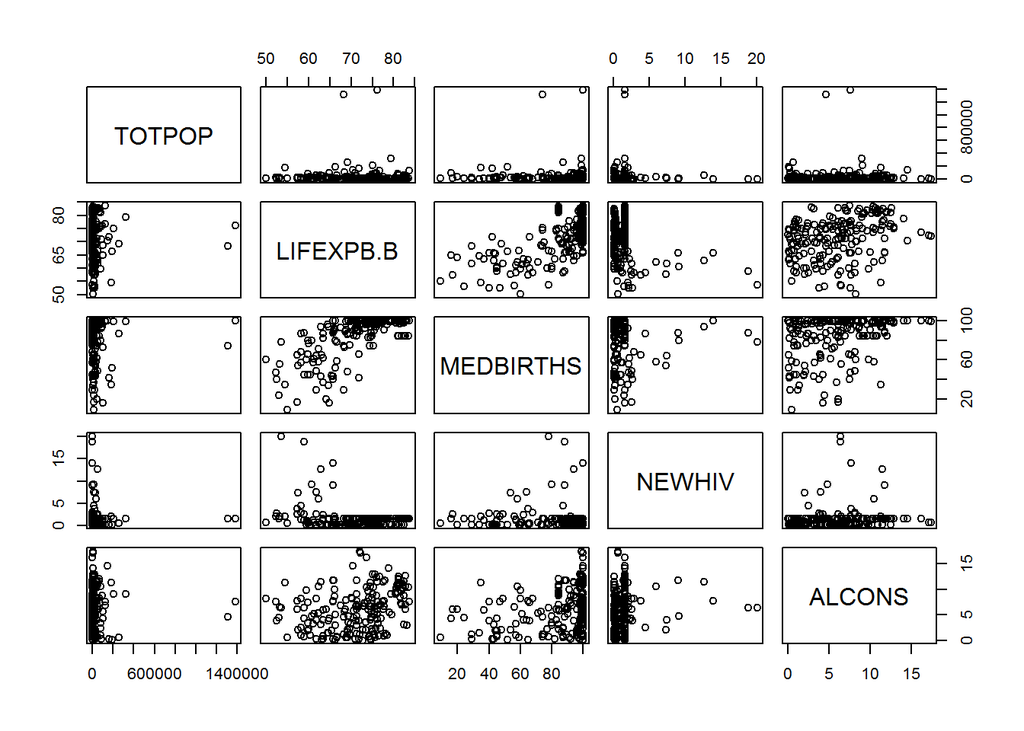

```r
pairs(whsAnnBdatNum[,c(1,4,7,10,17)])
```

In some way this dataset is somewhat similar to the `USArrests` dataset extensively used in ISLR labs and exercises – it collects various continuous statistics characterizing human population across different territories. It is several folds larger though – instead of 50 US states and 4 attributes in `USArrests`, world health statistics (WHS) data characterizes 194 WHO member states by 37 variables. Have fun!

The following problems are largely modeled after labs and exercises from Chapter 10 ISLR. If anything presents a challenge, besides asking questions on piazza (that is always a good idea!), you are also encouraged to review corresponding lab sections in ISLR Chapter 10.

# Problem 1: Principal components analysis (PCA) (25 points)

The goal here is to appreciate the impact of scaling of the input variables on the result of the principal components analysis. To that end, you will first survey means and variances of the attributes in this dataset (sub-problem 1a) and then obtain and explore results of PCA performed on data as is and after centering and scaling each attribute to zero mean and standard deviation of one (sub-problem 1b).

## Sub-problem 1a: means and variances of WHS attributes (5 points)

Compare means and variances of the *untransformed* attributes in the world health statisics dataset – plot of variance vs. mean is probably the best given the number of attributes in the dataset. Function `apply` allows to apply desired function (e.g. `mean` or `var` or `sd`) to each row or column in the table. Do you see all 37 attributes in the plot, or at least most of them? (Remember that you can use `plot(inpX,inpY,log="xy")` to use log-scale on both horizontal and vertical axes.) Is there a dependency between attributes’ averages and variances? What is the range of means and variances when calculated on untransformed data? Which are the top two attributes with the highest mean or variance? What are the implications for PCA rendition of this dataset (in two dimensions) if applied to untransformed data?

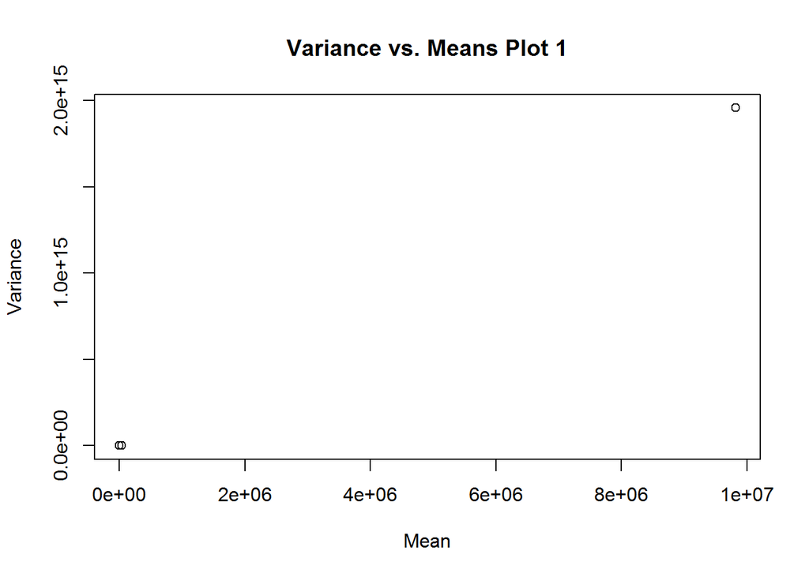

```r
# vectors for mean and variance of the variables(columns)
whs_matrix = data.matrix(whsAnnBdatNum)
means_x = apply(whs_matrix, MARGIN=2, FUN=mean) # all attribute means
vars_y = apply(whs_matrix, MARGIN=2, FUN=var) # all attribute variances

# plot untransformed of variance vs. mean
plot(means_x, vars_y, xlab="Mean", ylab="Variance", main="Variance vs. Means Plot 1")
```

```r
summary(means_x)
```

```
##    Min. 1st Qu.  Median    Mean 3rd Qu.    Max.
##       0      12      55  266396      73 9817345
```

```r
summary(vars_y)
```

```
##      Min.   1st Qu.    Median      Mean   3rd Qu.      Max.
## 0.000e+00 5.600e+01 1.730e+02 5.292e+13 1.063e+03 1.958e+15
```

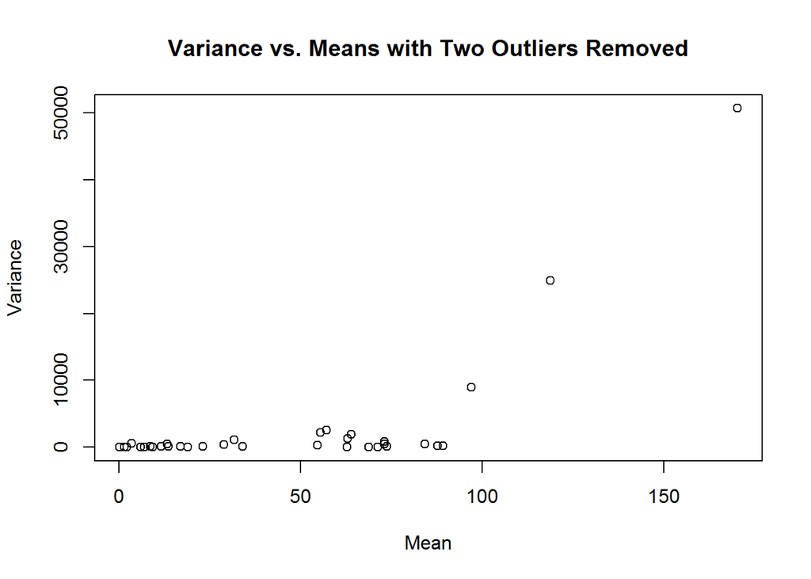

```r
# remove the first outlier
max_mean1 = max(means_x)
max_var1 = max(vars_y)
means_1 = means_x[means_x < max(means_x)] # rm max of means
vars_1 = vars_y[vars_y < max(vars_y)] # rm max of variances

# remove the scond outlier
max_mean2 = max(means_1)
max_var2 = max(vars_1)
means_2 = means_1[means_1 < max(means_1)] # rm max of means again
vars_2 = vars_1[vars_1 < max(vars_1)] # rm max of variances again

# untransformed plot without the two highest values
plot(means_2, vars_2, xlab="Mean", ylab="Variance", main="Variance vs. Means with Two Outliers Removed")
```

```r
# find what columns the outliers correspond to
# outlier/leverage 1 from whole attribute set
means_x[means_x == max_mean1]
```

```
## INTINTDS
##  9817345
```

```r
vars_y[vars_y == max_var1]
```

```
##     INTINTDS
## 1.958163e+15
```

```r
# outlier/leverage 2 from attribute set with first outlier removed
means_x[means_x == max_mean2]
```

```
##   TOTPOP
## 37695.96
```

```r
vars_y[vars_y == max_var2]
```

```
##      TOTPOP
## 19951911987
```

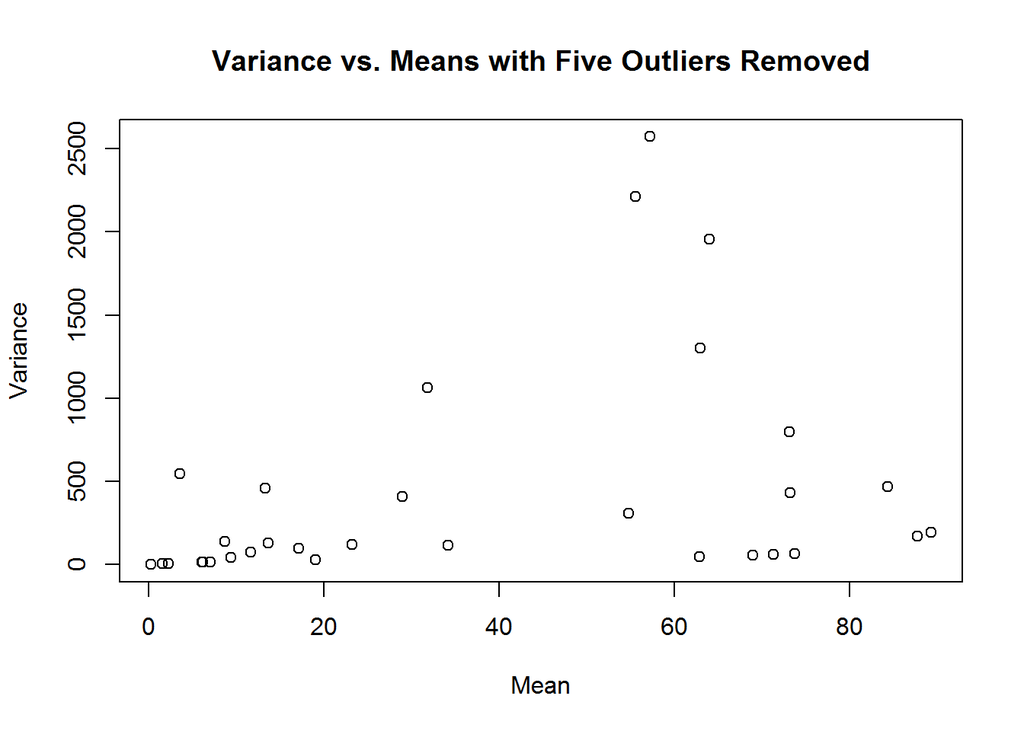

```r
# futher plot
means_3 = means_2[means_2 < 90] # 90 came from testing, excludes 5 outliers
vars_3 = vars_2[vars_2 < 5000] # 5000 also came from testing, excludes 5 outliers
plot(means_3,vars_3, xlab="Mean", ylab="Variance", main="Variance vs. Means with Five Outliers Removed")
```

There is no clear dependency between the means and variances of the attributes in the data set. On the second plot, which has the two highest values for mean and variance removed, there seems to be no association between mean and variance, except for the three points furthest to the right. Plot 3 shows an even closer view with the three far right points removed, and still no dependency found.

The range for means is from 0 to 9817345 for the non-transformed attributes. The range for the variances is from 0 to 1.958e+15. The first point with highest mean and variance is attribute INTINTDS. The second point with highest mean and variance is TOTPOP.

If PCA was applied without transforming the data, the result would display arbitrary ranges for the principle components (PCs). We would see heavy influence from outlier/leverage attributes such as INTINTDS and TOTPOP explain a disproporionate amount of variance compared to the other attributes. As a result, no clear associations can be made between the attributes and among the observations, even though they may be important in the context of classifying our data.

## Sub-problem 1b: PCA on untransformed and scaled WHS data (20 points)

Perform the steps outlined below *both* using *untransformed* data and *scaled* attributes in WHS dataset (remember, you can use R function `prcomp` to run PCA and to scale data you can either use as input to `prcomp` the output of `scale` as applied to the WHS data matrix or call `prcomp` with parameter `scale` set to `TRUE`). To make it explicit, the comparisons outlined below have to be performed first on the unstransformed WHS data and then again on scaled WHS data – you should obtain two sets of results that you could compare and contrast.

1. Obtain results of principal components analysis of the data (by using `prcomp`)

```r
pca_untransformed = prcomp(whsAnnBdatNum, scale=FALSE)
pca_transformed = prcomp(whsAnnBdatNum, scale=TRUE)

dim(pca_untransformed$x)
```

```
## [1] 194  37
```

2. Generate scree plot of PCA results (by calling `plot` on the result of `prcomp`)

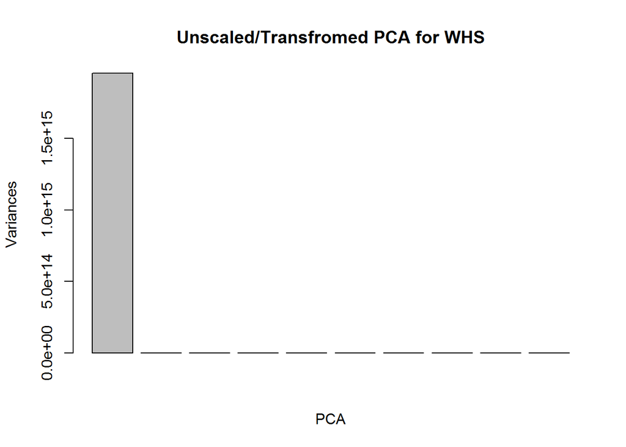

```r
plot(pca_untransformed, xlab="PCA", main="Unscaled/Transfromed PCA for WHS")
```

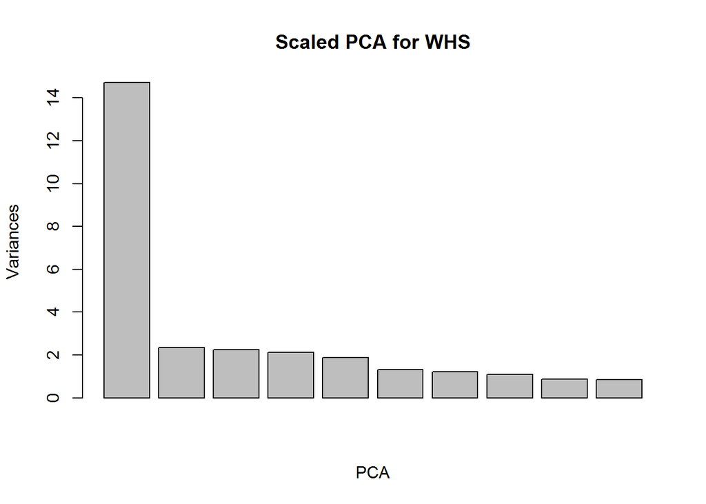

```r
plot(pca_transformed, xlab="PCA", main="Scaled PCA for WHS")
```

3. Generate plot of the two first principal components using `biplot`. Which variables seem to predominantly drive the results of PCA when applied to untransformed data?

[output not shown]

[output cut: 49 more lines]

[output not shown]

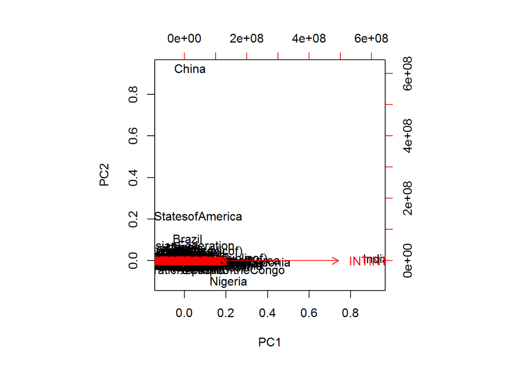

```r
biplot(pca_untransformed)
```

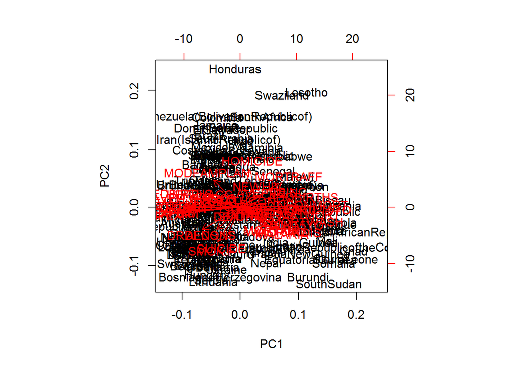

```r
biplot(pca_transformed)
```

- Please note that in case of untransformed data you should expect `biplot` to generate substantial number of warnings. Usually in R we should pay attention to these and understand whether they indicate that something went wrong in our analyses. In this particular case they are expected – why do you think that is?

While running the biplot() function, a “zero-length arrow is of indeterminate angle and so skipped” error appears. This appears because the arrows are too small to fit on the plot due to their very small variance compared to the two largest variances. This happens for almost all the variables except TOTPOP and INTINTDS, which are plotted properly.

4. The field `rotation` in the output of `prcomp` contains *loadings* of the 1st, 2nd, etc. principal components (PCs) – that can interpreted as contributions of each of the attributes in the input data to each of the PCs.

```r
#pca_untransformed$rotation[,1:2]
#abs(pca_transformed$rotation[,1:2])

whs_pca_nonscale_abs = abs(pca_untransformed$rotation[,1:2])
whs_pca_scale_abs = abs(pca_transformed$rotation[,1:2])

# max for nonscaled WHS PC1
whs_pca_nonscale_abs[,1][whs_pca_nonscale_abs[,1] == max(whs_pca_nonscale_abs[,1])]
```

```
##  INTINTDS
## 0.9999975
```

```r
# max for nonscaled WHS PC2
whs_pca_nonscale_abs[,2][whs_pca_nonscale_abs[,2] == max(whs_pca_nonscale_abs[,2])]
```

```
##    TOTPOP
## 0.9999974
```

```r
# max for scaled WHS PC1
whs_pca_scale_abs[,1][whs_pca_scale_abs[,1] == max(whs_pca_scale_abs[,1])]
```

```
## LIFEXPB.F
## 0.2530785
```

```r
# max for scaled WHS PC2
whs_pca_scale_abs[,2][whs_pca_scale_abs[,2] == max(whs_pca_scale_abs[,2])]
```

```
##  HOMICIDE
## 0.3912347
```

- What attributes have the largest (by their absolute value) loadings for the first and second principal component?

- How does it compare to what you have observed when comparing means and variances of all attributes in the world health statistics dataset?

Compared to the findings in 1a of the means and variances of all the attributes, the findings for PC1 and PC2 are the same as the outliers/leverage points for the largest and second largest means and variances. We found that INTINTDS had the largest mean and variance of all the attributes so it makes sense that PC1 would capture INTINTDS variance. And similarly, TOTPOP had the second largest mean and variance among the attributes and is captured by PC2, which captrues the second largest source of variance.

5. Calculate percentage of variance explained (PVE) by the first five principal components (PCs). You can find an example of doing this in ISLR Chapter 10.4 (Lab 1 on PCA).

```r
# first five PVE for nonscaled data
pr_noscale_var = pca_untransformed$sdev^2
pve_noscale = pr_noscale_var/sum(pr_noscale_var)
pve_noscale[1:5]
```

```
## [1] 9.999947e-01 5.275169e-06 3.305817e-11 9.177458e-12 2.340102e-12
```

```r
# first five PVE fro scaled data
pr_scale_var = pca_transformed$sdev^2
pve_scale = pr_scale_var/sum(pr_scale_var)
pve_scale[1:5]
```

```
## [1] 0.39787072 0.06346391 0.06065473 0.05743585 0.05101508
```

Now that you have PCA results when applied to untransformed and scaled WHS data, please comment on how do they compare and what is the effect of scaling? What dataset attributes contribute the most (by absolute value) to the top two principal components in each case (untransformed and scaled data)? What are the signs of those contributions? How do you interpret that?

Scaling does not bias the Principle Component Analysis of data with large measurement magnitudes. We saw that in the unscaled data, there was a heavy bias for INTINTDS (PC1) and TOTPOP (PC2), which have very large ranges and large variances. Scaling ensures that the data’s attributes have consistant variances that are comparable and not dependent on the range by normalizing the mean and standard of deviations. This makes the variances more interpretable and resulted in a max PC1 for LIFEXPB.F and max PC2 for HOMICIDE.